# Causal ML for Treatment Outcomes: Smoking, BMI, and Diabetes

### 10.2 Step 2 — CATE from the full g-formula

```r
cate_df <- do.call(rbind, lapply(levels(cohort$bmi_grp), function(g) {
  sub <- cohort[cohort$bmi_grp == g, ]
  if (nrow(sub) < 30) return(NULL)
  m  <- lm(delta_bmi ~ quit + bmi0 + age + sex + fam_hx + alcohol + activity, data = sub)
  o  <- glm(diabetes  ~ quit + delta_bmi + bmi0 + age + sex + fam_hx + alcohol + activity,
            data = sub, family = binomial)
  f  <- function(tv) {
    d <- sub; d$quit <- tv; d$delta_bmi <- predict(m, newdata = d)
    mean(predict(o, newdata = d, type = "response"))
  }
  p1 <- f(1); p0 <- f(0)
  data.frame(bmi_grp = g, n = nrow(sub),
             p_smoke = round(p0, 4),
             p_quit  = round(p1, 4),
             cate    = round(p1 - p0, 4))
}))

knitr::kable(cate_df,
  col.names = c("BMI group", "n", "P(T2D | do(quit=0))",
                "P(T2D | do(quit=1))", "CATE"),
  caption = paste0(
    "CATE by baseline BMI group (g-formula). ",
    "A positive CATE means quitting increases short-term T2D risk in that group. ",
    "Note that differences in baseline T2D risk across BMI groups (p_smoke column) ",
    "affect the absolute CATE even when the log-odds effect is similar, ",
    "because P(1-P) varies — see Section on scale interpretation."))
```

CATE by baseline BMI group (g-formula). A positive CATE means quitting increases short-term T2D risk in that group. Note that differences in baseline T2D risk across BMI groups (p_smoke column) affect the absolute CATE even when the log-odds effect is similar, because P(1-P) varies — see Section on scale interpretation.

| BMI group | n | P(T2D \| do(quit=0)) | P(T2D \| do(quit=1)) | CATE |
| --- | --- | --- | --- | --- |
| < 22 | 508 | 0.0098 | 0.0000 | -0.0098 |
| 22-25 | 727 | 0.0087 | 0.0060 | -0.0027 |
| 25-28 | 542 | 0.0059 | 0.0257 | 0.0198 |
| >= 28 | 223 | 0.0906 | 0.0701 | -0.0205 |

**Interpreting the CATE table carefully**

The CATE values reflect **both** the treatment heterogeneity of interest (BMI-mediated extra weight gain) **and** differences in baseline T2D prevalence across BMI groups (which changes the $P(1-P)$ scaling factor even for the same log-odds effect). A large negative CATE in the $\geq 28$ group does not necessarily mean quitting is more beneficial there — it may simply reflect higher baseline T2D risk in that group, which amplifies all effects on the probability scale.

The mediator table in Step 1 is therefore the cleaner test of the heterogeneity claim: if “extra gain from quitting” increases monotonically across BMI groups, the mechanism is confirmed regardless of the probability-scale CATE pattern.

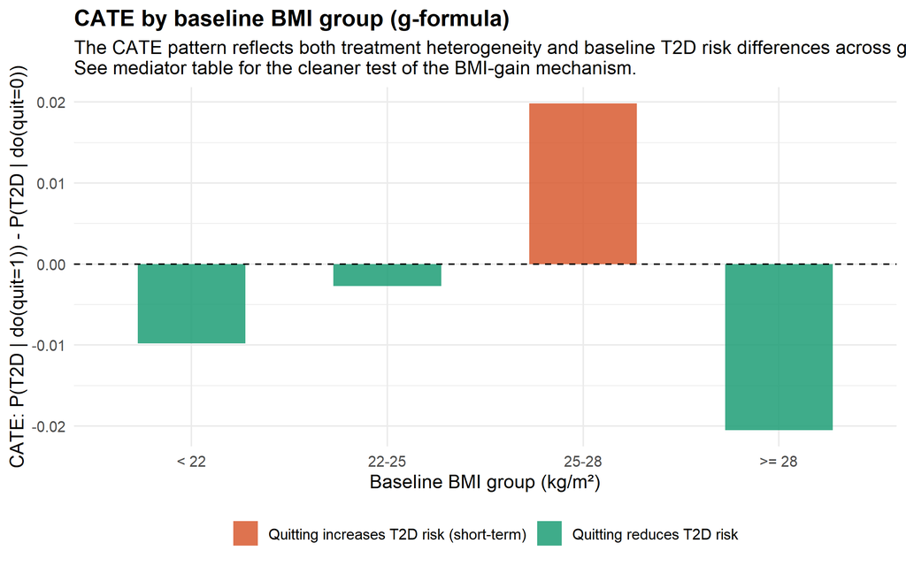

CATE by BMI group. A positive bar (red) means quitting increases short-term T2D risk in that group via weight gain. The pattern should be interpreted alongside the mediator table above.

```r
cate_df$bmi_grp <- factor(cate_df$bmi_grp, levels = levels(cohort$bmi_grp))

ggplot(cate_df, aes(x = bmi_grp, y = cate, fill = cate < 0)) +
  geom_col(width = 0.55, alpha = 0.85) +
  geom_hline(yintercept = 0, linetype = "dashed") +
  scale_fill_manual(
    values = c("FALSE" = "#D85A30", "TRUE" = "#1D9E75"),
    labels = c("FALSE" = "Quitting increases T2D risk (short-term)",
               "TRUE"  = "Quitting reduces T2D risk")
  ) +
  labs(
    title    = "CATE by baseline BMI group (g-formula)",
    subtitle = paste0("The CATE pattern reflects both treatment heterogeneity",
                      " and baseline T2D risk differences across groups.\n",
                      "See mediator table for the cleaner test of the BMI-gain mechanism."),
    x    = "Baseline BMI group (kg/m²)",
    y    = "CATE: P(T2D | do(quit=1)) - P(T2D | do(quit=0))",
    fill = NULL
  ) +
  theme_minimal(base_size = 12) +
  theme(plot.title = element_text(face = "bold"), legend.position = "bottom")
```

## 11 Summary

```r
knitr::kable(
  data.frame(
    Finding = c(
      "Naïve ML ATE (biased)",
      "G-formula ATE (causal)",
      "Absolute bias",
      "Proportion of total effect mediated via ΔBMI",
      "Direct protective effect of quitting (ADE)"
    ),
    Value = c(
      sprintf("%.4f", ate_naive),
      sprintf("%.4f  [95%% CI: %.4f, %.4f]", ate_gform, ci_gform[1], ci_gform[2]),
      sprintf("%.4f", abs(ate_naive - ate_gform)),
      sprintf("%.1f%%", med_out$n0 * 100),
      sprintf("%.4f  [95%% CI: %.4f, %.4f]", med_out$z0,
              med_out$z0.ci[1], med_out$z0.ci[2])
    )
  ),
  caption = "Key results"
)
```

Key results

| Finding | Value |
| --- | --- |
| Naïve ML ATE (biased) | -0.0085 |
| G-formula ATE (causal) | -0.0016 [95% CI: -0.0117, 0.0133] |
| Absolute bias | 0.0069 |
| Proportion of total effect mediated via ΔBMI | -114.8% |
| Direct protective effect of quitting (ADE) | -0.0084 [95% CI: -0.0198, 0.0038] |

## 12 References

Bush, Timothy, Jennifer C. Lovejoy, Mona Deprey, and Kelly M. Carpenter. 2016. “The Effect of Tobacco Cessation on Weight Gain, Obesity, and Diabetes Risk.” *Obesity* 24 (9): 1834–41. https://doi.org/10.1002/oby.21582.

Cho, Sung Keun et al. 2024. “Longitudinal Analysis of Diabetes Mellitus Risk: Smoking Status and Smoking Cessation.” *Journal of Clinical Medicine* 13 (13): 3927. https://doi.org/10.3390/jcm13133927.

Feuerriegel, Stefan, Dennis Frauen, Valentyn Melnychuk, Jonas Schweisthal, Konstantin Hess, Alicia Curth, Stefan Bauer, Niki Kilbertus, Isaac S. Kohane, and Uri Shalit. 2024. “Causal Machine Learning for Predicting Treatment Outcomes.” *Nature Medicine* 30 (4): 958–68. https://doi.org/10.1038/s41591-024-02902-1.

Hu, Yang, Geng Zong, Gang Liu, Molin Wang, Bernard Rosner, An Pan, Walter C. Willett, JoAnn E. Manson, Frank B. Hu, and Qi Sun. 2018. “Smoking Cessation, Weight Change, Type 2 Diabetes, and Mortality.” *New England Journal of Medicine* 379 (7): 623–32. https://doi.org/10.1056/NEJMoa1803626.

Imai, Kosuke, Luke Keele, and Dustin Tingley. 2010. “A General Approach to Causal Mediation Analysis.” *Psychological Methods* 15 (4): 309–34. https://doi.org/10.1037/a0020761.